# EXECUTIVE STRATEGY REPORT DATASET: 126,130 STEAM PC GAMES

### Question 8: Do Indie titles get higher review scores than commercial titles despite lower prices?

**What this visual shows**: Direct head-to-head comparison of Indie vs. Commercial games on review score (%) and average price ($).

**Stakeholder Takeaway**: Leverage studio authenticity and fair pricing to cultivate a loyal, vocal fan base.

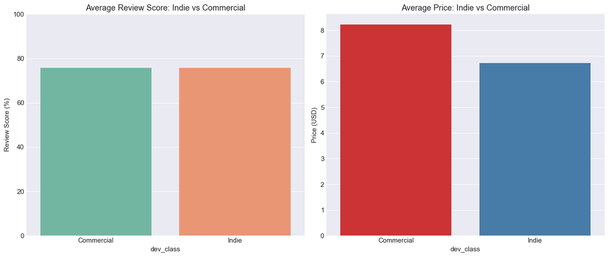

```python
# Question 8: Indie vs Commercial
# Define 'Indie' as Publisher == Developer, or primary genre is Indie
df['is_indie'] = ((df['publishers'] == df['developers']) | (df['primary_genre'] == 'Indie'))
df['dev_class'] = np.where(df['is_indie'], 'Indie', 'Commercial')

indie_comp = df.groupby('dev_class').agg(
    avg_score=('review_score_pct', 'mean'),
    avg_price=('price', 'mean')
).reset_index()

fig, (ax1, ax2) = plt.subplots(1, 2, figsize=(14, 6))

sns.barplot(data=indie_comp, x='dev_class', y='avg_score', ax=ax1, palette='Set2')
ax1.set_title('Average Review Score: Indie vs Commercial')
ax1.set_ylim(0, 100)
ax1.set_ylabel('Review Score (%)')

sns.barplot(data=indie_comp, x='dev_class', y='avg_price', ax=ax2, palette='Set1')
ax2.set_title('Average Price: Indie vs Commercial')
ax2.set_ylabel('Price (USD)')

plt.tight_layout()
plt.show()
```

## Section 3: Quality vs. Real Business Outcomes

### Question 9: Does review score predict ownership, or do marketing reach & CCU matter far more?

**What this visual shows**: Correlation comparison testing Review Score vs. Store Recommendations vs. Peak Concurrent Players.

> 💡 **Key Market Finding**:
> - Quality Score has Near-Zero Direct Link to Sales: A 95% rating guarantees nothing if the game lacks discovery.
> - Virality & CCU Spikes Dominate: Concurrent player surges and store visibility (recommendations) propel titles into Steam's top-seller algorithms.

**Stakeholder Takeaway**: Allocate at least 30% of total project budget to streamer outreach, creator keys, and visibility campaigns.

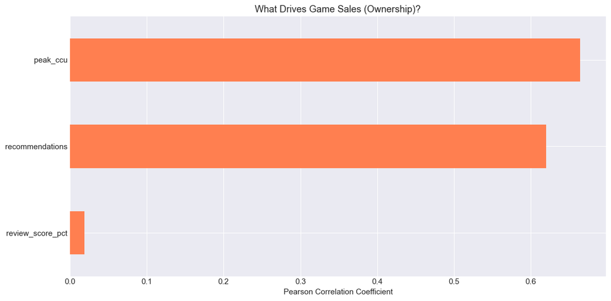

```python
# Question 9: Correlation comparison
corr_vars = ['highest_estimate_owner', 'review_score_pct', 'recommendations', 'peak_ccu']
corr_data = df[corr_vars].dropna().corr()[['highest_estimate_owner']].drop('highest_estimate_owner')
corr_data = corr_data.rename(columns={'highest_estimate_owner': 'Correlation with Ownership'}).sort_values('Correlation with Ownership', ascending=True)

plt.figure(figsize=(10, 5))
corr_data.plot(kind='barh', legend=False, color='coral')
plt.title('What Drives Game Sales (Ownership)?')
plt.xlabel('Pearson Correlation Coefficient')
plt.tight_layout()
plt.show()
```